# Comparison of Peak Times Across Years in Fuji

2024-09-06

#### Objective：

This analysis examines whether significant changes occurred in peak visitor times at various stations along the 吉田 Trail of Mount Fuji from July 2022 to 2024.

#### Research Thinking：

To evaluate whether there were significant changes in peak visitor times from July 2022 to 2024, the time with the highest daily visitor count was defined as the peak time of the day. Analyses were conducted separately for three stations along the 吉田 Trail of Mount Fuji: the trailhead, halfway station, and mountain station. Trends in peak visitor times for each station were plotted, and the Wilcoxon test was used to assess the significance of differences in peak times across the three years.

**Analysis using the Wilcoxon test:** The Wilcoxon test is a non-parametric test suitable for data that does not follow a normal distribution. Given the small sample size of peak time data and the non-normal distribution, the Wilcoxon test is more robust compared to other parametric tests. It also provides good statistical power for small sample sizes.

#### Research data：

Data bases: 2022/07, 2023/07, 2024/07

Selected **‘Trailhead location’**, **‘Half-way station’**, and **‘Mountain location’** of Mt. Fuji to check the number of people. Data Collection Summary: The number of visitors was collected within a 0.5 km radius buffer of the study destination.

- **Trailhead location**：富士スバルライン五合目-ビジターセンター https://www.fujisan-climb.jp/trails/yoshida/index.html

2022/7 = 2,482 people；2023/7 = 4,151 people；2024/7 = 1,759 people。

- **Half-way station**：本八合目トモエ館

2022/7 = 4,457 people；2023/7 = 4,287 people；2024/7 = 2,888 people。

- **Mountain location**：富士山頂上 山口屋

2022/7 = 6,475 people；2023/7 = 4,599 people；2024/7 = 3,825 people。

## 0 Extract daily peak hours

#### Raw data

```r
head(all_data)
```

```
##   富士山吉田登山口 男性 女性 X20代 X30代 X40代 X50代 X60代 X70歳以上 居住者
## 1              5時    0    0     0     0     0     0     0         0      0
## 2            5時半    0    0     0     0     0     0     0         0      0
## 3              6時    0    0     0     0     0     0     0         0      0
## 4            6時半    0    0     0     0     0     0     0         0      0
## 5              7時    0    0     0     0     0     0     0         0      0
## 6            7時半    0    0     0     0     0     0     0         0      0
##   勤務者 来街者 平均男性 平均女性 平均20代 平均30代 平均40代 平均50代 平均60代
## 1      0      0        0        0        0        0        0        0        0
## 2      0      0        0        0        0        0        0        0        0
## 3      0      0        0        0        0        0        0        0        0
## 4      0      0        0        0        0        0        0        0        0
## 5      0      0        0        0        0        0        0        0        0
## 6      0      0        0        0        0        0        0        0        0
##   平均70歳以上 平均居住者 平均勤務者 平均来街者     Date
## 1            0          0          0          0 20220701
## 2            0          0          0          0 20220701
## 3            0          0          0          0 20220701
## 4            0          0          0          0 20220701
## 5            0          0          0          0 20220701
## 6            0          0          0          0 20220701
```

##### To extract the peak visitor times of the day, identify the time period with the highest number of visitors and generate the “daily_max_flow” dataset.

```r
 # Data samples
print(daily_max_flow)
```

```
## # A tibble: 185 × 5
## # Groups:   Date [62]
##    Date       富士山吉田登山口 Time_Slot  Flow Year
##    <date>     <chr>            <chr>     <int> <chr>
##  1 2022-07-01 16時半           16:30        33 2022
##  2 2022-07-01 17時             17:00        33 2022
##  3 2022-07-01 17時半           17:30        33 2022
##  4 2022-07-01 18時             18:00        33 2022
##  5 2022-07-01 18時半           18:30        33 2022
##  6 2022-07-01 19時             19:00        33 2022
##  7 2022-07-02 6時              06:00        41 2022
##  8 2022-07-07 13時半           13:30        29 2022
##  9 2022-07-07 14時             14:00        29 2022
## 10 2022-07-07 14時半           14:30        29 2022
## # ℹ 175 more rows
```

**Time unit:** half an hour

**Flow：** number of people in the time period

Explanation：In this example, between 16:30 and 19:00 on 2022/7/1, the number of visitors recorded every half hour was 33, which was the highest number recorded that day. Therefore, the peak period for that day is defined as these six time points from 16:30 to 19:00. For 2 July, 6時 was the highest and the peak point.

## 1 *Trailhead*_Yearly Analysis of Peak Visitor Hours

### Trailhead location：富士スバルライン五合目-ビジターセンター

**（Analyse the frequency of occurrence of each peak hour）**

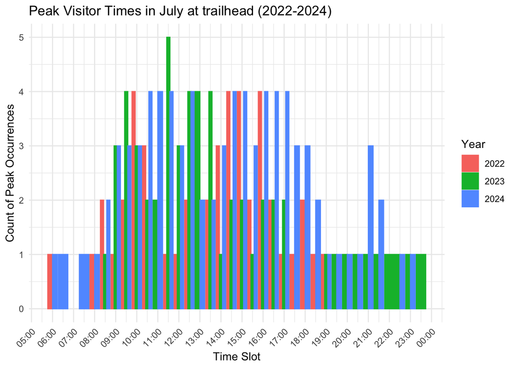

X-axis: indicates the different time periods of the day.

Y-axis: indicates the number of times these hours were selected as peak hours during the 31 days of July.

##### This chart shows the peak times at the trailhead point for the years 2022, 2023, and 2024.

- **Overall, Peak hour at trailhead in 2024 became later in the day**
- In 2022, the peak times were mainly between 1:00 PM and 4:00 PM.
- In 2023, the peak times were similar to 2022, also concentrated between 1:00 PM and 4:00 PM, with no significant changes.
- In 2024, the peak times were slightly delayed compared to the previous two years, concentrated between 2:00 PM and 5:00 PM.

### Wilcoxon test

##### To test whether there are significant changes in peak times between the years, the Wilcoxon test was used for significance testing.

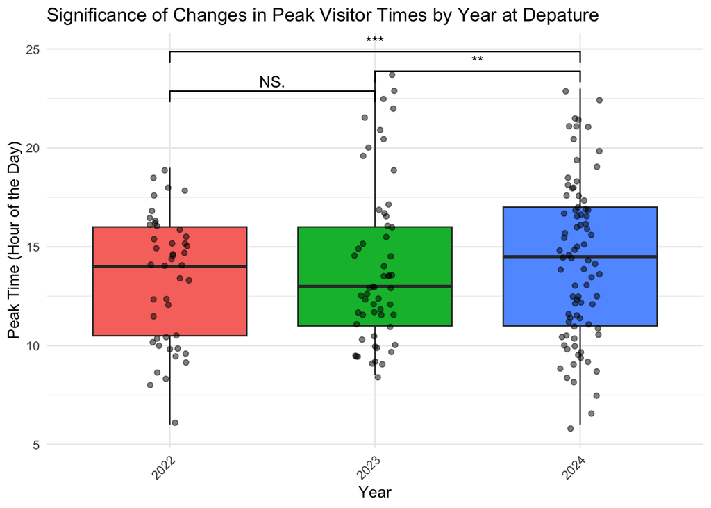

##### significance testing：

- There is no significant difference between 2022 and 2023.
- There is a significant difference between 2022 and 2024, with the peak times in 2024 being later.
- There is also a significant difference between 2023 and 2024, with a trend of delayed peak times.

## 2 Mountain_Yearly Analysis of Peak Visitor Hours

### **Mountain location**：富士山頂上 山口屋

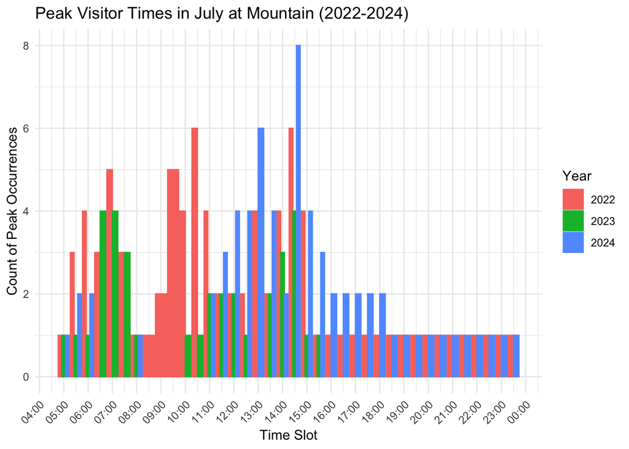

X-axis: indicates the different time periods of the day.

Y-axis: indicates the number of times these hours were selected as peak hours during the 31 days of July.

### Wilcoxon test

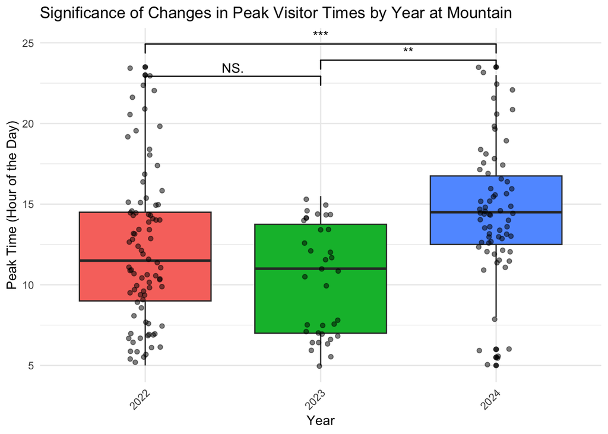

##### significance testing：

- There is no significant difference between 2022 and 2023; the peak times in these two years are quite close.
- There is a highly significant difference between 2022 and 2024, indicating a significant delay in peak times.
- There is a significant difference between 2023 and 2024, with a clear trend of delayed peak times.

## 3 Half_Yearly Analysis of Peak Visitor Hours

### **Half-way station**：本八合目トモエ館

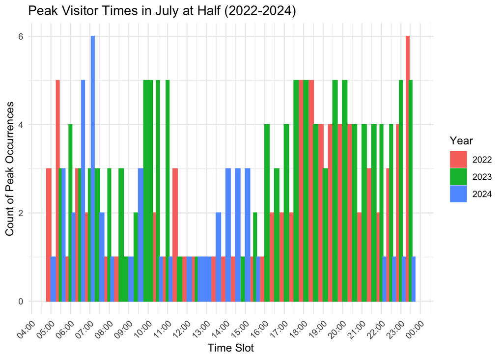

X-axis: indicates the different time periods of the day.

Y-axis: indicates the number of times these hours were selected as peak hours during the 31 days of July.

### Wilcoxon test

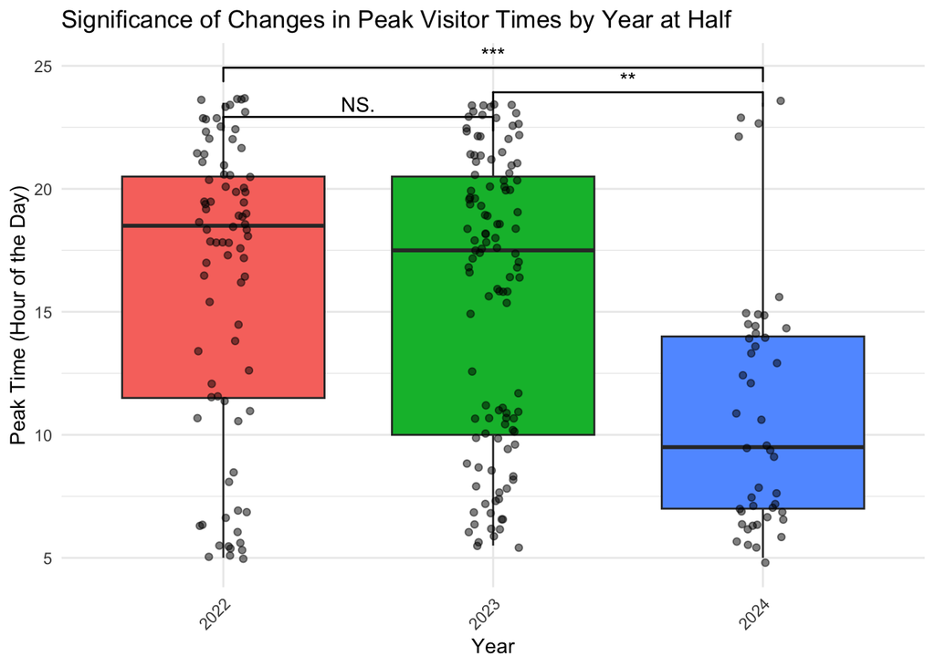

##### significance testing：

- There is no significant difference between 2022 and 2023; the peak times in these two years are quite similar.
- There is a significant difference between 2022 and 2024, with a noticeable shift to earlier peak times in 2024.
- There is a significant difference between 2023 and 2024, further indicating an earlier occurrence of peak times in 2024.

## 4 Data feasibility testing

To verify the reliability of the data：I compared the visitor data from the Trailhead with the daily visitor data recorded by MOE for the “吉田ルート” in July 2023 to verify the reliability of the analysis. Please note that the MOE data represents the total number of visitors per day and does not include the number of visitors at each time point.

MOE：https://kanto.env.go.jp/press_00050.html

##### Merging of the two data

- Daily_Total_Visitors：Number of daily visitors in Trailhead
- yoshida：：Number of daily visitors in WOE “吉田ルート”

```
##         Date Daily_Male_Female_Sum Daily_Generation_Sum Daily_Total_Visitors
## 1 2023-07-01                    60                   60                   60
## 2 2023-07-02                   102                  101                  102
## 3 2023-07-03                     0                    0                    0
## 4 2023-07-04                   106                  106                  106
## 5 2023-07-05                     0                    0                    0
## 6 2023-07-06                     0                    0                    0
##     X yoshida subashiri gotemba fujinomiya
## 1 125    1011        NA      NA         NA
## 2 126    2661        NA      NA         NA
## 3 127    1311        NA      NA         NA
## 4 128    1241        NA      NA         NA
## 5 129    1076        NA      NA         NA
## 6 130    1370        NA      NA         NA
```

##### Normality test

```
##
##  Shapiro-Wilk normality test
##
## data:  merged_data$Daily_Total_Visitors
## W = 0.82582, p-value = 0.0001613
```

```
##
##  Shapiro-Wilk normality test
##
## data:  merged_data$yoshida
## W = 0.90002, p-value = 0.007218
```

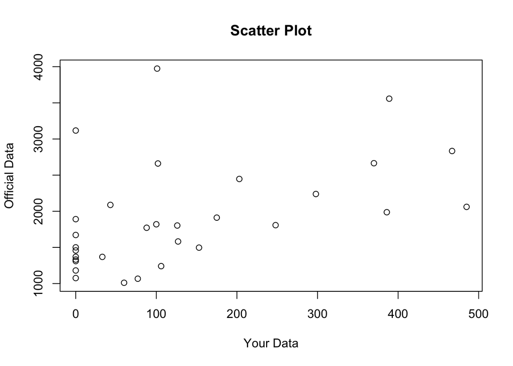

According to the results of the Shapiro-Wilk normality test, neither dataset follows a normal distribution, making the Spearman correlation test a more appropriate choice.

- For the KDDI dataset, the p-value is much less than 0.05, indicating that the data does not follow a normal distribution.
- For the MOE dataset, the p-value is also less than 0.05, showing that this data does not follow a normal distribution either.

##### Spearman correlation test

```
## [1] "The Spearman correlation between Daily_Total_Visitors and Yoshida for July 2023 is: 0.552206112213826"
```

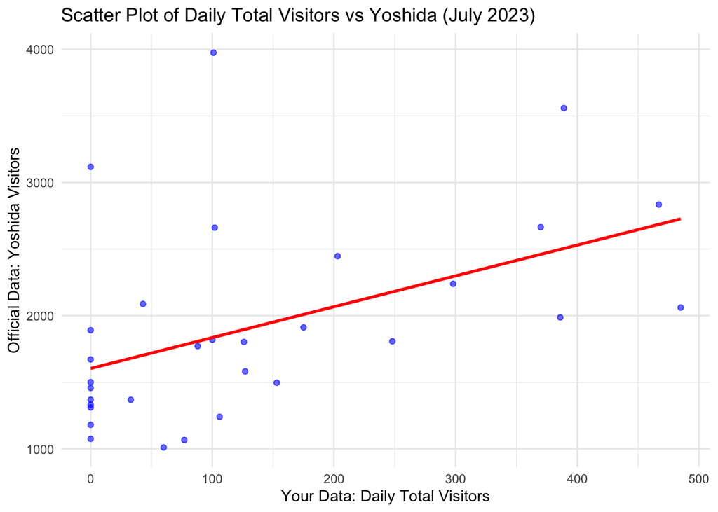

- The results indicate that the Spearman correlation coefficient is 0.552, suggesting a moderate positive correlation between the two variables. Although this relationship is not very strong, it is still statistically significant.

## 5 Summaries

- Peak hour at trailhead in 2024 became later in the day, median at around 14 pm
- Peak hour at mountain in 2024 became later in the day, median around 14 pm
- Peak hour at Half in 2024 became earlier in the day, median at around 9:00 am
- Moderate positive correlation between KDDI data and MOE